# Assignment 3: Verify the Claim - Philadelphia Poverty Change

- Show All Code
- Hide All Code
- View Source

Testing if ACS data supports the 2018 news story

Author

Gautami Kasat

Published

September 25, 2026

## The Enquiry

This report tests whether the ACS data supports the claims in Alfred Lubrano’s 2018 article, [“New Census figures on Philly neighborhoods show inequality, high numbers of whites living in poverty”](https://whyy.org/articles/new-census-figures-on-philly-neighborhoods-show-inequality-high-numbers-of-whites-living-in-poverty/) (WHYY / Philadelphia Inquirer, December 6, 2018).

## Part 1: Reconstruct

### Variables

I pulled four ACS variables. For overall poverty, B17001_002 counts people below the poverty level in the past twelve months, and B17001_001 gives the population for whom poverty status is determined. Because several claims are specifically about white poverty, I also pulled B17001A_001 and B17001A_002, the same table restricted to people identifying as white alone. ACS publishes counts, not rates, so both the rate and its margin of error have to be calculated. I used the 2006-2010 and 2013-2017 five-year estimates at the census tract level. Five-year estimates are the only ones that reach tracts; one-year estimates cover only areas of 65,000 people or more.

### Assumptions

The article does not document its method, so several choices are mine. It does not name the ACS table it used; I assumed B17001. It says “white” without defining it, so I used B17001A, white alone, which includes people who also identify as Hispanic. And it reports neighborhood figures, which are not Census geographies: its reporters aggregated tracts into boundaries of their own choosing and never published which tracts went where, so my numbers will not match theirs. Every figure in the article is a point estimate, with no margins of error given.

### Overlap

The two periods do not overlap. Census Bureau guidance is explicit that only non-overlapping five-year estimates should be compared over time, so on this point the article is on solid ground.

## Part 2: Test (code plus interpretation)

### Computing poverty rates

ACS publishes counts, not rates, so both the rate and its uncertainty have to be built. Dividing the count below poverty by the universe gives the rate; `moe_prop()` then combines the two margins of error into a margin of error for the resulting proportion. The count’s margin of error does not carry over.

**View Code**

```r
pov_2010 <- pov_2010 %>%
  mutate(
    pov_pct = pov_poorE / pov_totalE * 100,
    pov_moe = moe_prop(pov_poorE, pov_totalE, pov_poorM, pov_totalM) * 100,
    wht_pct = wht_poorE / wht_totalE * 100,
    wht_moe = moe_prop(wht_poorE, wht_totalE, wht_poorM, wht_totalM) * 100
    )
```

**View Code**

```r
pov_2017 <- pov_2017 %>%
  mutate(
    pov_pct = pov_poorE / pov_totalE * 100,
    pov_moe = moe_prop(pov_poorE, pov_totalE, pov_poorM, pov_totalM) * 100,
    wht_pct = wht_poorE / wht_totalE * 100,
    wht_moe = moe_prop(wht_poorE, wht_totalE, wht_poorM, wht_totalM) * 100
    )
```

### Assessing reliability

The coefficient of variation (CV) expresses the uncertainty as a share of the estimate, which makes estimates comparable. Following Jurjevich et al. (2018), I flagged a CV under 12% as reliable, 12 to 40% as somewhat reliable, and above 40% as unreliable.

**View Code**

```r
pov_2010 <- pov_2010 %>%
  mutate(
    pov_cv = (pov_moe/1.645) / pov_pct * 100,
    pov_reliability = case_when(
    pov_cv < 12 ~ "Reliable",
    pov_cv < 40 ~ "Somewhat reliable",
    pov_cv >= 40 ~ "Unreliable",
    TRUE ~ NA_character_
    )
  )
```

**View Code**

```r
pov_2010 <- pov_2010 %>%
  mutate(
    wht_cv = (wht_moe/1.645) / wht_pct * 100,
    wht_reliability = case_when(
    wht_cv < 12 ~ "Reliable",
    wht_cv < 40 ~ "Somewhat reliable",
    wht_cv >= 40 ~ "Unreliable",
    TRUE ~ NA_character_
    )
  )
```

**View Code**

```r
pov_2017 <- pov_2017 %>%
  mutate(
    pov_cv = (pov_moe/1.645) / pov_pct * 100,
    pov_reliability = case_when(
    pov_cv < 12 ~ "Reliable",
    pov_cv < 40 ~ "Somewhat reliable",
    pov_cv >= 40 ~ "Unreliable",
    TRUE ~ NA_character_
    )
  )
```

**View Code**

```r
pov_2017 <- pov_2017 %>%
  mutate(
    wht_cv = (wht_moe/1.645) / wht_pct * 100,
    wht_reliability = case_when(
    wht_cv < 12 ~ "Reliable",
    wht_cv < 40 ~ "Somewhat reliable",
    wht_cv >= 40 ~ "Unreliable",
    TRUE ~ NA_character_
    )
  )
```

### Observations

Reliability differs sharply between the two measures, and between the two periods. For overall poverty, 45 of 384 tracts were unreliable in 2006-2010, falling to 22 by 2013-2017. For white poverty the picture is far worse: 189 tracts, just under half the city, were unreliable in 2006-2010, improving to 111 by 2013-2017. This asymmetry matters because the article’s white poverty claims are claims about change, and a change is only as sound as its weaker endpoint. In roughly half of Philadelphia, that endpoint will not hold.

### Measuring change

To compare the two periods, each tract’s 2010 and 2017 rates have to sit in the same row, so I joined the two datasets on GEOID. The change itself is simple subtraction, but its uncertainty is not: a difference between two estimates is less certain than either estimate alone, and the two margins of error combine by squaring, adding, and taking the square root rather than by simple addition. Dividing the change by that combined standard error gives a z score, which says how large the movement is relative to the noise around it. At 90% confidence the threshold is 1.645: above it, the change is distinguishable from zero; below it, the data cannot establish that anything happened.

**View Code**

```r
pov_change <- pov_2010 %>%
  st_drop_geometry() %>%
  select(GEOID, NAME, pov_pct, pov_moe, wht_pct, wht_moe) %>%
  rename(pov_pct_10 = pov_pct, pov_moe_10 = pov_moe,
         wht_pct_10 = wht_pct, wht_moe_10 = wht_moe) %>%
  left_join(
    pov_2017 %>%
      select(GEOID, pov_pct, pov_moe, wht_pct, wht_moe) %>%
      rename(pov_pct_17 = pov_pct, pov_moe_17 = pov_moe,
             wht_pct_17 = wht_pct, wht_moe_17 = wht_moe),
    by = "GEOID"
  )
```

**View Code**

```r
pov_change <- pov_change %>%
  mutate(
    pov_change = pov_pct_17 - pov_pct_10,
    pov_se_diff = sqrt((pov_moe_10/ 1.645)^2 + (pov_moe_17/ 1.645)^2),
    pov_moe_diff = pov_se_diff * 1.645,
    pov_z = pov_change / pov_se_diff,
    pov_sig = abs(pov_z) > 1.645
    )
```

**View Code**

```r
pov_change <- pov_change %>%
  mutate(
    wht_change = wht_pct_17 - wht_pct_10,
    wht_se_diff = sqrt((wht_moe_10/ 1.645)^2 + (wht_moe_17/ 1.645)^2),
    wht_moe_diff = wht_se_diff * 1.645,
    wht_z = wht_change / wht_se_diff,
    wht_sig = abs(wht_z) > 1.645
    )
```

### Missing values

Eight tracts produce no poverty rate in one or both periods. Seven of them carry numbers in the 9803 to 9809 range, which the Census Bureau reserves for special land use tracts: large areas with little or no residential population, such as parks, airports, and industrial or employment zones.

The eighth, Tract 50, sits at the southern tip of the city along the Delaware and behaves the same way. In all eight, the population for whom poverty status can be determined is effectively zero, so there is no rate to compute and the `NA` is correct rather than a gap in the data. I excluded them from the tract counts that follow.

Six further tracts drop out of the white poverty analysis for a different reason. Each has a measurable white poverty rate in one period but not the other, because the white population for whom poverty status could be determined was zero in the other period. Tract 103 is the clearest case: a white poverty rate of 100% in 2006-2010 and no measurable white population at all by 2013-2017. With no second endpoint there is no change to test, so these tracts are excluded from the white analysis but retained in the overall one.

**View Code**

```r
count(pov_change, pov_sig)
```

```
# A tibble: 2 × 2
  pov_sig     n
  <lgl>   <int>
1 FALSE     313
2 TRUE       63
```

### How many tracts changed

Of the 376 tracts with a measurable poverty rate in both periods, 63 show a change that is statistically distinguishable from zero at 90% confidence. The remaining 313, just over 83%, do not. That does not mean poverty held steady in those tracts; it means the data cannot establish that it moved. For most of Philadelphia, the margin of error on a seven-year change is wider than the change itself.

**View Code**

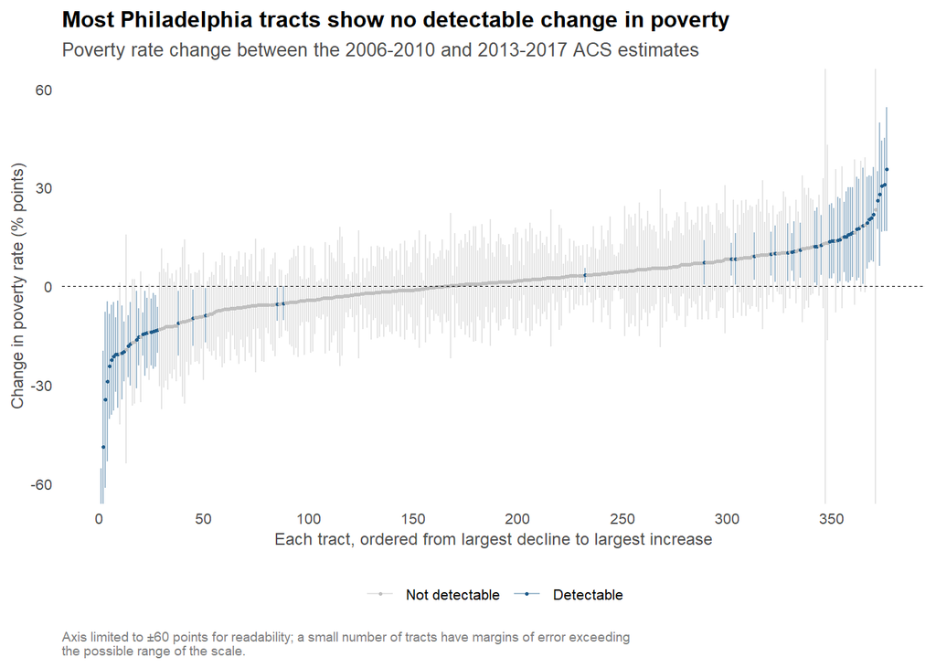

```r
pov_change  %>%
  arrange(pov_change) %>%
  mutate(rank = row_number()) %>%
  ggplot(aes(x = rank, y = pov_change)) +
  geom_errorbar(aes(ymin = pov_change - pov_moe_diff,
                    ymax = pov_change + pov_moe_diff,
                    color = pov_sig),
                    width = 0, alpha = 0.4)+
  geom_point(aes(color = pov_sig), size = 0.5)+
  scale_color_manual(
    values = c("TRUE" = "#1f5c8b", "FALSE" = "grey75"),
    labels = c("TRUE" = "Detectable", "FALSE" = "Not detectable"),
    name = NULL
  ) +
  geom_hline(yintercept = 0, linetype = "dashed", linewidth = 0.3) +
  scale_x_continuous(breaks = seq(0, 376, by = 50)) +
  coord_cartesian(ylim = c(-60, 60)) +
  theme_minimal() +
  theme(
    plot.title = element_text(size = 12, face = "bold"),
    plot.subtitle = element_text(size = 10, color = "grey30"),
    plot.caption = element_text(size = 7, color = "grey50", hjust = 0),
    axis.title = element_text(size = 9, color = "grey30"),
    axis.text = element_text(size = 8),
    legend.text = element_text(size = 8),
    legend.position = "bottom",
    panel.grid = element_blank()
  ) +
  labs(
    title = "Most Philadelphia tracts show no detectable change in poverty",
    subtitle = "Poverty rate change between the 2006-2010 and 2013-2017 ACS estimates",
    caption = str_wrap("Axis limited to ±60 points for readability; a small number of tracts have margins of error exceeding the possible range of the scale.", 100),
     x = "Each tract, ordered from largest decline to largest increase",
    y = "Change in poverty rate (% points)"
  )
```

## Where the article’s smallest numbers come from

The article’s most striking white poverty figures are its smallest: 2% in Holmesburg, 1% in Mayfair. The first table below shows the fifteen tracts with the lowest white poverty rates in 2006-2010, the period those claims start from. Thirteen of the fifteen are unreliable.

**View Code**

```r
pov_2010 %>%
   filter(!is.na(wht_pct), wht_pct > 0, wht_pct < 10) %>%
  arrange(wht_pct) %>%
  slice_head(n = 15) %>%
  mutate(
    dot = case_when(
      wht_cv < 12 ~ "🟢",
      wht_cv <= 40 ~ "🟡",
      TRUE ~ "🔴"
    ),
    NAME = str_remove(NAME, ", Philadelphia County, Pennsylvania")
  ) %>%
  select(dot, NAME, wht_pct, wht_moe, wht_cv, wht_reliability) %>%
  gt() %>%
  fmt_number(columns = c(wht_pct, wht_moe, wht_cv), decimals = 1) %>%
  cols_label(
    dot = "",
    NAME = "Tract",
    wht_pct = "Rate (%)",
    wht_moe = "MOE",
    wht_cv = "CV (%)",
    wht_reliability = "Reliability"
  ) %>%
  cols_align(align = "center", columns = dot) %>%
  tab_header(
    title = "The lowest white poverty rates are the least reliable",
    subtitle = "Fifteen tracts with the lowest white poverty rates, 2006-2010 ACS"
  ) %>%
  tab_source_note(
    "Reliability thresholds follow Jurjevich et al. (2018): CV < 12% reliable, 12-40% somewhat reliable, > 40% unreliable."
  )
```

The lowest white poverty rates are the least reliable

Fifteen tracts with the lowest white poverty rates, 2006-2010 ACS

|  | Tract | Rate (%) | MOE | CV (%) | Reliability |
| --- | --- | --- | --- | --- | --- |
| 🔴 | Census Tract 236 | 0.9 | 1.4 | 97.7 | Unreliable |
| 🔴 | Census Tract 384 | 1.2 | 1.1 | 53.9 | Unreliable |
| 🔴 | Census Tract 220 | 1.6 | 2.6 | 95.9 | Unreliable |
| 🔴 | Census Tract 267 | 2.0 | 2.9 | 90.0 | Unreliable |
| 🔴 | Census Tract 305.02 | 2.3 | 2.1 | 57.3 | Unreliable |
| 🟡 | Census Tract 351 | 2.3 | 1.4 | 36.0 | Somewhat reliable |
| 🔴 | Census Tract 10.01 | 2.3 | 2.7 | 70.3 | Unreliable |
| 🔴 | Census Tract 339 | 2.4 | 2.9 | 75.7 | Unreliable |
| 🔴 | Census Tract 365.02 | 2.4 | 2.0 | 51.3 | Unreliable |
| 🟡 | Census Tract 352 | 2.7 | 1.6 | 37.2 | Somewhat reliable |
| 🔴 | Census Tract 136.01 | 2.8 | 2.4 | 51.2 | Unreliable |
| 🔴 | Census Tract 308 | 2.9 | 1.9 | 40.2 | Unreliable |
| 🔴 | Census Tract 255 | 3.4 | 3.8 | 66.4 | Unreliable |
| 🔴 | Census Tract 61 | 3.5 | 4.5 | 78.5 | Unreliable |
| 🔴 | Census Tract 270 | 3.5 | 3.7 | 65.0 | Unreliable |

Reliability thresholds follow Jurjevich et al. (2018): CV < 12% reliable, 12-40% somewhat reliable, > 40% unreliable.

#### The same problem at the other end of the scale

The second table shows the opposite end of the range, and the picture barely improves. Only two of the fifteen highest rates are reliable, and eight report a rate of exactly 100% with margins of error between 117 and 236 percentage points, on a scale that can only run from 0 to 100. The problem is not the size of the rate. It is the size of the population underneath it: a tract with a dozen white residents produces an unusable estimate whether the rate comes out at 2% or 100%.

**View Code**

```r
pov_2010 %>%
   filter(!is.na(wht_pct), wht_pct > 0) %>%
  arrange(desc(wht_pct)) %>%
  slice_head(n = 15) %>%
  mutate(
    dot = case_when(
      wht_cv < 12 ~ "🟢",
      wht_cv <= 40 ~ "🟡",
      TRUE ~ "🔴"
    ),
    NAME = str_remove(NAME, ", Philadelphia County, Pennsylvania")
  ) %>%
  select(dot, NAME, wht_pct, wht_moe, wht_cv, wht_reliability) %>%
  gt() %>%
  fmt_number(columns = c(wht_pct, wht_moe, wht_cv), decimals = 1) %>%
  cols_label(
    dot = "",
    NAME = "Tract",
    wht_pct = "Rate (%)",
    wht_moe = "MOE",
    wht_cv = "CV (%)",
    wht_reliability = "Reliability"
  ) %>%
  cols_align(align = "center", columns = dot) %>%
  tab_header(
    title = "Even the highest white poverty rates are mostly unreliable",
    subtitle = "Fifteen tracts with the highest white poverty rates, 2006-2010 ACS"
  ) %>%
  tab_source_note(
    "Reliability thresholds follow Jurjevich et al. (2018): CV < 12% reliable, 12-40% somewhat reliable, > 40% unreliable."
  )
```

Even the highest white poverty rates are mostly unreliable

Fifteen tracts with the highest white poverty rates, 2006-2010 ACS

|  | Tract | Rate (%) | MOE | CV (%) | Reliability |
| --- | --- | --- | --- | --- | --- |
| 🔴 | Census Tract 83.01 | 100.0 | 214.2 | 130.2 | Unreliable |
| 🔴 | Census Tract 103 | 100.0 | 217.6 | 132.3 | Unreliable |
| 🔴 | Census Tract 106 | 100.0 | 235.7 | 143.3 | Unreliable |
| 🔴 | Census Tract 151.02 | 100.0 | 178.1 | 108.3 | Unreliable |
| 🔴 | Census Tract 152 | 100.0 | 117.3 | 71.3 | Unreliable |
| 🔴 | Census Tract 167.02 | 100.0 | 189.6 | 115.3 | Unreliable |
| 🔴 | Census Tract 174 | 100.0 | 218.6 | 132.9 | Unreliable |
| 🔴 | Census Tract 31 | 100.0 | 181.2 | 110.1 | Unreliable |
| 🟢 | Census Tract 88.01 | 95.0 | 17.3 | 11.1 | Reliable |
| 🔴 | Census Tract 279.02 | 92.3 | 119.7 | 78.9 | Unreliable |
| 🟡 | Census Tract 203 | 88.6 | 18.6 | 12.8 | Somewhat reliable |
| 🟡 | Census Tract 364 | 87.2 | 19.8 | 13.8 | Somewhat reliable |
| 🟢 | Census Tract 147 | 85.8 | 5.9 | 4.2 | Reliable |
| 🔴 | Census Tract 145 | 85.4 | 85.9 | 61.1 | Unreliable |
| 🟡 | Census Tract 88.02 | 85.0 | 18.1 | 13.0 | Somewhat reliable |

Reliability thresholds follow Jurjevich et al. (2018): CV < 12% reliable, 12-40% somewhat reliable, > 40% unreliable.

Across the city the pattern holds. Of Philadelphia’s 384 tracts in 2006-2010, just 6 produce a white poverty rate that meets the standard threshold for reliability: 1.6% of the city. Another 189 tracts, 49.2%, are unreliable outright, and 10 more yield no rate at all. The article builds several of its sharpest claims on a measure that works in six tracts out of 384.

### Why the estimates fail

**View Code**

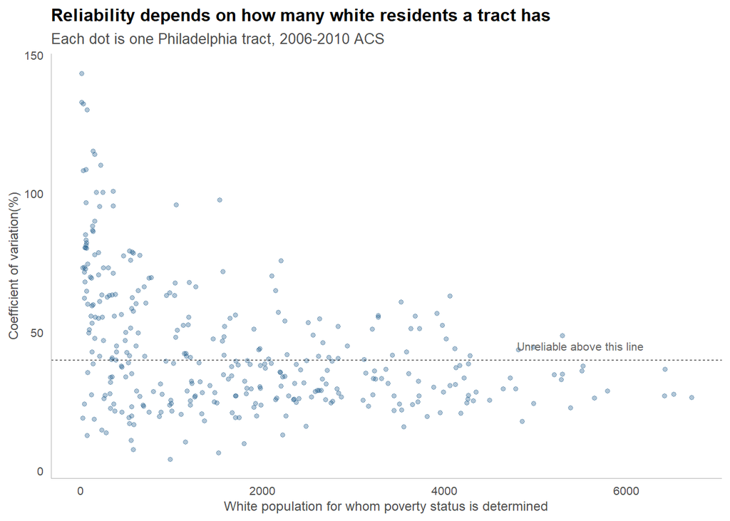

```r
pov_2010 %>%
  filter(!is.na(wht_cv), !is.infinite(wht_cv), wht_cv < 200) %>%
  ggplot(aes(x = wht_totalE, y = wht_cv)) +
  geom_point(alpha = 0.35, size = 1.2, color = "#1f5c8b") +
  geom_hline(yintercept = 40, linetype = "dashed", linewidth = 0.3)+
  annotate("text", x = 5500, y = 45, label = "Unreliable above this line",
           size = 2.8, color = "grey40", hjust = 0.5) +
  theme_minimal() +
  theme(
    plot.title = element_text(size = 12, face = "bold"),
    plot.subtitle = element_text(size = 10, color = "grey30"),
    axis.title = element_text(size = 9, color = "grey30"),
    axis.text = element_text(size = 8),
    panel.grid = element_blank(),
    axis.line = element_line(linewidth = 0.2, color = "grey70")
  ) +
  labs(
    title = "Reliability depends on how many white residents a tract has",
    subtitle = "Each dot is one Philadelphia tract, 2006-2010 ACS",
    x = "White population for whom poverty status is determined",
    y = "Coefficient of variation(%)"
  )
```

Of the 370 tracts with a measurable white poverty rate in both periods, 72 show a change that is statistically detectable and 298 do not.

### The citywide rate

**View Code**

```r
city_2017 <- pov_2017 %>%
  st_drop_geometry() %>%
  summarise(
    poor_total = sum(pov_poorE, na.rm = TRUE),
    poor_moe = moe_sum(pov_poorM, pov_poorE, na.rm = TRUE),
    univ_total = sum(pov_totalE, na.rm = TRUE),
    univ_moe = moe_sum(pov_totalM, pov_totalE, na.rm = TRUE)
  ) %>%
  mutate(
    city_rate = poor_total / univ_total * 100,
    city_moe = moe_prop(poor_total, univ_total, poor_moe, univ_moe) * 100
  )

city_2017
```

```
  poor_total poor_moe univ_total univ_moe city_rate  city_moe
1     393924  8321.62    1526582 10140.92  25.80431 0.5174618
```

## Part 3 : Adjudicate

**Supported:** The citywide poverty rate of 26% holds: aggregating all 384 tracts gives 25.8%, margin of error half a percentage point. This is the article’s largest-scale claim and its most secure one, because summing 384 tracts shrinks the relative error to a fraction of what it is in any single tract. The article is also right not to compare overlapping periods.

**Not supported:** The citywide white poverty figure (14.8% to 19.4%) comes from a one-year survey dropped into a story otherwise built on five-year estimates; Census guidance says not to compare the two. The framing fails too. Of 376 tracts, 36 show a detectable increase, 27 show a detectable decline the article never mentions, and 313 show no change distinguishable from zero. That is not a city sliding into poverty. It is a city where most places held steady and the rest moved both ways.

**Cannot be determined:** Philadelphia neighborhoods are not Census geographies, and the reporters never published which tracts they aggregated into which neighborhood. Fairhill’s 61%, Eastwick’s 12% to 26%, Holmesburg’s 2% to 19%, Mayfair’s 1% to 14%, and the 22-neighborhood claim are therefore uncheckable. The white poverty claims fail twice over: only 6 of 384 tracts produce a reliable white poverty rate, and 189 are unreliable outright. A 1% or 2% rate in a tract with few white residents is not a precise measurement of a small number. It is an imprecise measurement that lands on one.

## Part 4: Rewrite

Rewriting the article’s opening paragraph:

> A new five-year federal survey puts Philadelphia’s poverty rate at about 26%, a figure the data supports with precision. What it does not support is a story of a city uniformly sliding into poverty. The Census divides Philadelphia into roughly 380 small statistical areas. Between the 2006-2010 and 2013-2017 surveys, fewer than 10% of them show a poverty increase large enough to be told apart from survey error. About 7% show a decrease. The remaining 83% moved too little, or were measured too imprecisely, to say either way. The survey is weakest where the headlines are loudest: in half the city it cannot measure white poverty reliably at all, because too few white residents live there to sample well. Philadelphia’s poverty is real and citywide. Whether it is rising or falling block by block is mostly beyond what this data can show.